# ECON 142 - Applied Econometrics & Public Policy

## <a href = "https://github.com/vviers/AN-Project"> Network Analysis of Voting Behaviors in the French National Assembly </a>

### Final Project, Vincent Viers

# Table of Content

- Intro
  - Research Questions
  - Some quick and basic useful facts about the French National Assembly
  - Data Cleaning
  - Data Description
  - Building Yearly Adjacency Matrices
- I) Exploratory Data Analysis
  - Using 2012 as an example of a (much too) dense networks.
  - "Sparsity"/Normalization of the Networks.
  - Yearly Analysis
- II) A Simple (and context-relevant!) Measure of Centrality
  - The Lobbyist Model
  - Wave 1 influence and Wave 2 (cascading) Influence
  - Monte-Carlo Simulation
  - Analysis
- ANNEX: All Years Together EDA

# INTRO

It is a well-known fact in politics that elected officials should not only be judged by what they say, but more importantly by what they do. To this end, little is more useful than a Member of Parliament's actual voting beheavior when in office. The work of [Lucioni (2013)](https://renzo.lucioni.xyz/senate-voting-relationships/), for example, was able to show an increasing degree of political polarization in the US Senate voting relationships over time.

While voting behvior analysis has been around for a while now, very little has been done in the French context as voting data was not readily available to researchers. In recent years, however, the French National Assembly has made available all kinds of data as part of its "Open Government" effort — among which are **all recorded votes spanning the previous legislature (2012 - 2017)** which can be downloaded as an XML file.

The [14th legislature](https://en.wikipedia.org/wiki/14th_legislature_of_the_French_Fifth_Republic) (June 2012 - early 2017) of the French National Assembly, under President François Hollande (Socialist Party), was a bumpy ride to say the least. Indeed, the government took a fairly liberal turn starting in 2014, which angered some MPs from the majority, some of whom even seceded from the majority and refused to back the government's legislative proposals. I hope to be able to visualize this in my project.

## Research Questions

My two main motivating questions for this project are the following:

> Can we observe shifts in political alliances and allegiances throughout the 2012 - 2016 French legislative exercise via voting-based networks?

> Can MPs' historical voting behaviors be used to determine whom are the most influential / central nodes in the MP network?

I start by providing a quick discussion of the (tedious) data wrangling process (done separately for the sake of space). I then move on to the descriptive network analysis of yearly voting behaviors among MPs and discuss a simple way to sparsify the networks in order to make them more manageable and relevant for analysis. My visual results are quite unconclusive due to network visualisation limitations.

I then present a simple and context-relevant model of node centrality. Using a 2 waves model of influence propagation, I am able to rank MPs according to their political gravitas.

## `Some quick and basic useful facts about the French National Assembly:`

- Members of Parliaments (*Députés*) are elected for 5-years mandates shortly after the Presidential election. Because of the timing of the two elections, the President's political party usually gets a majority of the seats at the National Assembly and can therefore efficiently govern throughout his mandate.
- The National Assembly is composed of 577 MPs. However, it is quite typical that an MP does not sit in the National Assembly for 5 years for several reasons:
  - MPs can become ministers, and therefore leave their seat to their substitute/alternate MP
  - Some MP's mandates are revoked for electoral fraud or misbehavior and another "partial" election sometimes takes place.
- The President of the National Assembly never votes. As we will see, this observation is quite important for the upcoming analysis.

# Data Cleaning

### (more details available in `Vote_Assemblee_Nationale_Adjacency_Matrix.ipynb` and `Generate_Data.ipynb`) in this project's <a href = "https://github.com/vviers/AN-Project"> Github repo </a>).

The Data Cleaning portion of this project was very long and tedious because of the way the XML data was stored.

- I started by downloading the XML file from the <a href = "http://data.assemblee-nationale.fr/">National Assembly's open data website </a> and scrapping each recorded ballot's ID, date, and basic info.
- I then shortlisted a list of 129 most important ballots i.e. those concerning the entierty of a law proposal. I am therefore excluding the thousands of votes on very specific amendments and where only a couple dozen MPs (max!) vote. Typically these ballots start with "l'ensemble de la proposition de loi..." or "la proposition de loi..."(in `other_data/list_ballots.csv`).
- Then, I looped over the XML file in order to collect, for each of the aforementionned important ballots, the list of MP*IDs present and whether they voted for or against the law proposal (or whether they abstained). I was then able to create a symmetric adjacency matrix $D$ for each ballot where $[D]*{ij} = 1$ if MPs i and j voted the same way.
- Finally, I downloaded a list of MPs that matched a MP's administrative ID with her real name and added this information to my adjacency matrices.

All resulting adjacency matrices csv are stored in: `'/adjacency_matrices/data{YEAR}_vote{NUM_VOTE}.csv'`

**A final note on the data**: I was not able to match each MP with her political party — which would have been very interesting and is left for future work. Being able to color each node according to their political affiliation could really help visualization. For now, I am only able to "manually" check my results (also known as googling).

```python
# Import Libraries

import pandas as pd
import numpy as np
import matplotlib.pyplot as plt
%matplotlib inline
import seaborn as sns
sns.set_context("notebook")
import warnings
warnings.filterwarnings('ignore')
plt.style.use('ggplot')

import networkx as nx
```

Read Data generated in `Generate_Data.ipynb`

Each csv file corresponds to the adjacency matrix between all present MPs for one single ballot.

```python
# Import and store all adjacency_matrices - by year.

import os

path = os.getcwd() + '/adjacency_matrices/'
ballots2012 = [pd.read_csv(path + 'data2012_vote{}.csv'.format(i), index_col = 0) for i in range(10)]
ballots2013 = [pd.read_csv(path + 'data2013_vote{}.csv'.format(i), index_col = 0) for i in range(51)]
ballots2014 = [pd.read_csv(path + 'data2014_vote{}.csv'.format(i), index_col = 0) for i in range(29)]
ballots2015 = [pd.read_csv(path + 'data2015_vote{}.csv'.format(i), index_col = 0) for i in range(16)]
ballots2016 = [pd.read_csv(path + 'data2016_vote{}.csv'.format(i), index_col = 0) for i in range(20)]
```

```python
# Create a list of *all* ballots.
allballots = ballots2016 + ballots2015 + ballots2014 + ballots2013 + ballots2012
```

I listed metadata about all used ballots in `other_data/list_ballots.csv` (see `Generate_Data.ipynb`)

```python
list_ballots = pd.read_csv("other_data/list_ballots.csv")
list_ballots.sample(5)
```

|  | ballot | date | title | year |
| --- | --- | --- | --- | --- |
| 123 | 48 | 30/10/2012 | l'ensemble du projet de loi de financement de ... | 2012 |
| 16 | 1274 | 24/05/2016 | l'ensemble du projet de loi de modernisation d... | 2016 |
| 103 | 510 | 23/04/2013 | l'ensemble du projet de loi ouvrant le mariage... | 2013 |
| 127 | 30 | 09/10/2012 | l'ensemble du projet de loi portant création d... | 2012 |
| 50 | 913 | 14/10/2014 | l'ensemble du projet de loi relatif à la trans... | 2014 |

```python
list_ballots.iloc[3, 2]
# Traduction: "The integrity of the finances law for 2017 (first reading). + links I did not clean."
```

```
"l'ensemble du projet de loi de finances pour 2017 (première lecture). [dossier] [analyse du scrutin]"
```

## Data Description

Here, I provide some basic summary statistics of my yearly data.

Number of Observations for each year:

```python
list_ballots.groupby('year').count().iloc[:, 0]
```

```
year
2012    10
2013    51
2014    29
2015    16
2016    23
Name: ballot, dtype: int64
```

The most part of the legislative work is typically done within the first year of a President's mandate (here, 2013). This is when big reforms promised during the campaign are implemented.

Average number of voting MPs for each year.

```python
print("2012. Mean: {}".format(np.average([len(i) for i in ballots2012])))
print("2013. Mean: {}".format(np.average([len(i) for i in ballots2013])))
print("2014. Mean: {}".format(np.average([len(i) for i in ballots2014])))
print("2015. Mean: {}".format(np.average([len(i) for i in ballots2015])))
print("2016. Mean: {}".format(np.average([len(i) for i in ballots2016])))
```

```
2012. Mean: 541.0
2013. Mean: 532.5882352941177
2014. Mean: 535.3103448275862
2015. Mean: 554.875
2016. Mean: 528.25
```

The average number of voting MPs seems stable over the years. Furthermore, my choice of "important" ballots seems to be doing a good job at getting a high proportion of MPs for each ballot (remember that there are 577 MPs in total).

Let's also compute and plot some summary statistics about the full data i.e. ballots accross all years:

```
N: 126
Mean: 536.0238095238095
Standard Deviation: 546.5
p10: 506.0
p25: 530.0
Median: 546.5
p75: 557.0
p90: 566.5
```

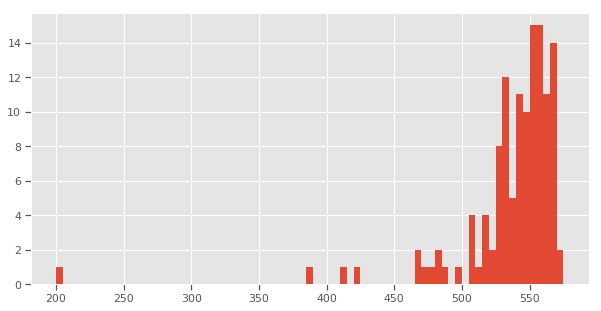

```python
print("N: {}".format(len(allballots)))
print("Mean: {}".format(np.average([len(i) for i in allballots])))
print("Standard Deviation: {}".format(np.median([len(i) for i in allballots])))
print("p10: {}".format(np.percentile([len(i) for i in allballots], 10)))
print("p25: {}".format(np.percentile([len(i) for i in allballots], 25)))
print("Median: {}".format(np.median([len(i) for i in allballots])))
print("p75: {}".format(np.percentile([len(i) for i in allballots], 75)))
print("p90: {}".format(np.percentile([len(i) for i in allballots], 90)))

plt.figure(figsize = (10, 5));
plt.hist([len(i) for i in allballots], bins = np.arange(200, 578, 5));
```

With the exception of 1 outlier, most of the ballots under consideration have a large MP presence.

#### Let's now create yearly adjacency matrices

```python
MPS2012 = list([i.index.tolist() for i in ballots2012]) #store list of voting MPs for each 2012 ballot
MPS2013 = list([i.index.tolist() for i in ballots2013]) #store list of voting MPs for each 2013 ballot
MPS2014 = list([i.index.tolist() for i in ballots2014]) #store list of voting MPs for each 2014 ballot
MPS2015 = list([i.index.tolist() for i in ballots2015]) #store list of voting MPs for each 2015 ballot
MPS2016 = list([i.index.tolist() for i in ballots2016]) #store list of voting MPs for each 2016 ballot
```

```python
MPSall = list([i.index.tolist() for i in allballots]) #store list of voting MPs for all ballots
```

```python
# unique voters
allvoters2012 = np.unique(np.concatenate(MPS2012))
allvoters2013 = np.unique(np.concatenate(MPS2013))
allvoters2014 = np.unique(np.concatenate(MPS2014))
allvoters2015 = np.unique(np.concatenate(MPS2015))
allvoters2016 = np.unique(np.concatenate(MPS2016))
```

```python
allvoters = np.unique(np.concatenate(MPSall))
```

It might be worth stopping here to make the data building strategy as clear as possible since several approaches are possible. For example, what I originally did was to only focus on MPs who had voted in *all* ballots and drop those who had missed a ballot. However, this approach made me loose a significant amount of MPs.

**What I do**: Each MP who voted *at least once* throughout the year is included in the yearly matrix. This procedure is less robust to events like an MP being revoked in the middle of the year, but this allows me to maximize the size of my networks.

```python
# Make all adjacency matrices the same size by reshaping them to the list of unique MPs
# and filling NAs with 0.

ballots2012 = [i.loc[allvoters2012, allvoters2012].fillna(0) for i in ballots2012]
ballots2013 = [i.loc[allvoters2013, allvoters2013].fillna(0) for i in ballots2013]
ballots2014 = [i.loc[allvoters2014, allvoters2014].fillna(0) for i in ballots2014]
ballots2015 = [i.loc[allvoters2015, allvoters2015].fillna(0) for i in ballots2015]
ballots2016 = [i.loc[allvoters2016, allvoters2016].fillna(0) for i in ballots2016]
```

```python
allballots = [i.loc[allvoters, allvoters].fillna(0) for i in allballots]
```

What is the number of unique MPs (i.e. the size of our networks) for each year?

```python
print("Size (overall): {}".format(np.unique([i.shape for i in allballots])))
print("Size (2012): {}".format(np.unique([i.shape for i in ballots2012])))
print("Size (2013): {}".format(np.unique([i.shape for i in ballots2013])))
print("Size (2014): {}".format(np.unique([i.shape for i in ballots2014])))
print("Size (2015): {}".format(np.unique([i.shape for i in ballots2015])))
print("Size (2016): {}".format(np.unique([i.shape for i in ballots2016])))
```

```
Size (overall): [636]
Size (2012): [577]
Size (2013): [583]
Size (2014): [605]
Size (2015): [583]
Size (2016): [592]
```

As mentionned before, some MPs come and go for various reasons. It is therefore normal that the full network is not always 577.

### Building Yearly Adjacency Matrices

For now, we have an unweighted adjacency matrix for each ballot $b$ i.e.

$$ D_b = \begin{bmatrix} d_{11} & d_{12} & d_{13} & \dots & d_{1n} \\ d_{21} & d_{22} & d_{23} & \dots & d_{2n} \\ \vdots \\ d_{n1} & d_{n2} & d_{n3} & \dots & d_{nn} \end{bmatrix} $$

where $D_b$ is the square and diagonal adjacency matrix of size $(n \times n)$ with $n$ the total number of MPs under consideration for ballot $b$:

$$[D_b]_{ij} = 1, \quad \text{if MP i and MP j voted in the same way (For, Against, Abstention)}$$ and zero otherwise.

By assumption, we do not allow self-loops:

$$[D_b]_{ii} = 0, \quad \forall i$$

Things start getting more interesting once we're adding all adjacency matrices together over the course of a year and dividing the resulting matrix by the total number of ballots during the year:

$$P = \frac{1}{B}\sum_{b = 1}^B D_b$$ where $B$ is the total number of ballots in a given year.

It is easy to see that the entries of matrix P will be equal to the empirical frequencies of similar voting for any two MPs i and j:

$$[P]_{ij} = \frac{\sum_{b = 1}^B [D_b]_{ij}}{B} = \frac{\text{# of times i and j voted the same way}}{\text{# of ballots}}$$

This, as we will see later, could be roughly interpreted as the probability (or historical frequency to be more precise) that MP i and j will vote in the same way.

Let us note that these "probabilities" will be slightly downward biased since MPs are sometimes simply not present at each ballot (and get a row of 0 on these ballots by default).

The following function `yearly_matrix()` creates such yearly matrix $P$ from a list of matrices $D$:

```python
def yearly_matrix(ballots, probability = True):
    """returns a numpy adjacency matrix of all MPs on a given year.
    if probability = True ==> returns a matrix with empirical frequencies in (0, 1) of similar voting behavior."""
    matrices = [np.array(i) for i in ballots]
    fulladj = sum(matrices)
    if (probability == False):
        return fulladj
    else : return fulladj/len(ballots)
```

NB: `yearly_matrix(., probability = False)` would simply return the matrix with the total number of times two MPs voted the same way.

# Exploratory Data Analysis

### In this section, I show the challenges associated with analysing very dense networks and propose a simple method to sparsify them, using the 2012 data only for now.

Because of the nature of adjacency matrix $P$ as defined above, I am using **weighted, undirected graphs** throughout the analysis.

```python
ballot = nx.from_numpy_matrix(yearly_matrix(ballots2012), parallel_edges=False) #create network
```

Renaming each nodes with actual MP's full names:

```python
mapping = dict(zip(ballot.nodes(), ballots2012[0].index)) # create mapping node/MP
ballot = nx.relabel_nodes(ballot, mapping, copy = False) # rename nodes
```

The president of the National Assembly (**Claude Bartolone**) is of course present at each ballot, but never votes. We drop him to ensure that our graph is fully connected (he is an *isolate* i.e has degree = 0).

```python
list(nx.isolates(ballot))
```

```
['Claude Bartolone']
```

```python
ballot.remove_nodes_from(list(nx.isolates(ballot))) # remove isolates
```

Let's first visualize the network and print its density and diameter. The following spectral layout for plotting networks basically pushes less central nodes (as measured by their eigenvector-centrality, roughly) to the outskirt of the graph.

**Warning**: this is (very) messy as I am also printing names in order to be able to check outliers.

```
Density: 0.9353442028985507, Diameter: 2
```

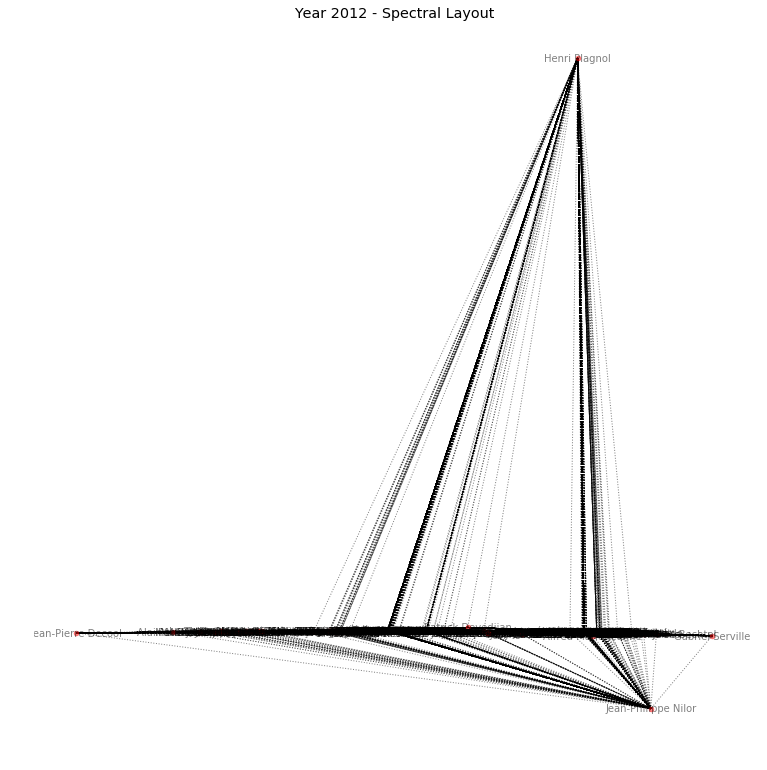

```python
plt.figure(figsize=(10, 10))
nx.draw_spectral(ballot, node_size=100, node_shape = '.', linewidths=None,
                 alpha = 0.5, with_labels = True, style = 'dotted', font_size = 10)
plt.title('Year 2012 - Spectral Layout')
print('Density: {}, Diameter: {}'.format(nx.density(ballot), nx.diameter(ballot)))
```

Three main "outliers":

> *Henri Plagnol*: was elected in the summer of 2012 but his mandate was revoked in October 2012 after he was found to have cheated during the campaign.

> *Jean-Philippe Nilor*: Martiniquais Independentist (one of France's overseas territory) ==> not aligned with any mainstream party.

> *Jean-Pierre Decool*: from the independent right, but joined the main opposition party from which he seceded along with 60-ish other MPs from November 2012 to January 2013.

All of the above 3 MPs seem good 'candidates' for non-standard voting behavior i.e. outliers.

The diameter of the network is 2. This makes a lot of sense: as soon as at least two MPs from usually diverging groups agree on at least one occasion, the graph will be connected.

Density: $\frac{2 \times |E|}{|V|(|V|-1)} \approx 0.935$

The graph is very dense since most pairs of MPs at least voted the same way on one occasion over the year. Another way of interpreting this number is that **only $6.5 \%$ of all pairs of MP never voted the same way in 2012.**

We can see the density of the network with the following visualization:

```
Text(0.5,1,'2012: A Very Dense Network')
```

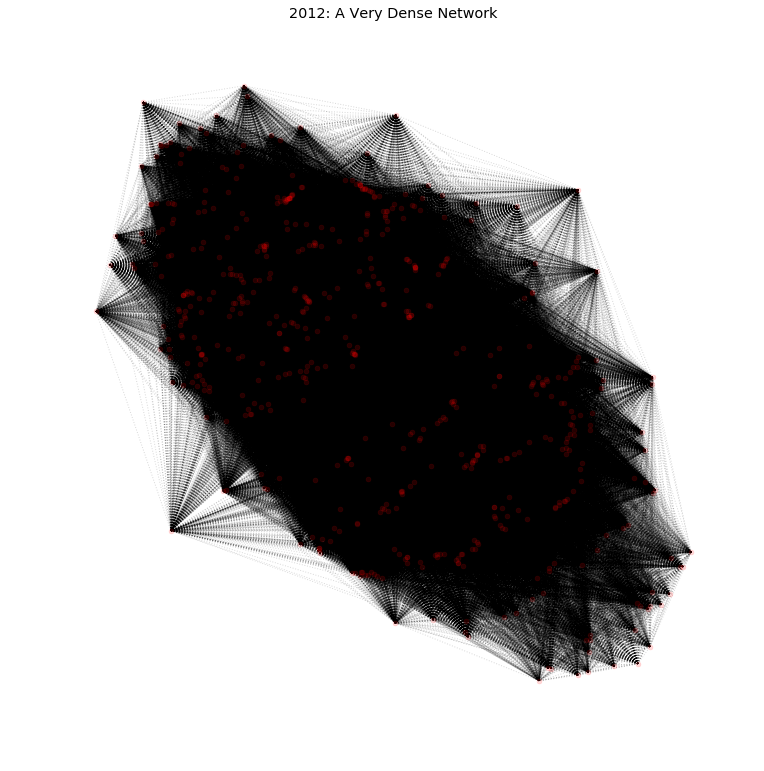

```python
plt.figure(figsize=(10, 10))
nx.draw_spring(ballot, node_size=100, node_shape = '.', linewidths=None,
                 alpha = 0.15, with_labels = False, style = 'dotted')
plt.title('2012: A Very Dense Network');
```

As we can see, nothing can be said visually from such a dense network.

For now, then, a key takeaway of the analysis is that we should figure out a way to "sparsify" the network so that it's easier to see patterns.

**One way of decreasing the density of the network is to delete edges whose weights fall below a certain threshold.** For example, using a threshold of 0.3 :

```python
P = yearly_matrix(ballots2012, probability=True)
print("There are {} edges in the network.".format(np.count_nonzero(P) / 2))
```

```
There are 154893.0 edges in the network.
```

```python
threshold = P < .3
P[threshold] = 0
print("There are now {} edges in the network.".format(np.count_nonzero(P) / 2))
```

```
There are now 94974.0 edges in the network.
```

```python
(154893.0 - 94974.0)/154893.0
```

```
0.386841238790649
```

We have decreased the number of edges in the network by about 40% !

Let's see what this sparser graph looks like:

```python
ballot = nx.from_numpy_matrix(P, parallel_edges=False)
mapping = dict(zip(ballot.nodes(), ballots2012[0].index)) # create mapping node/MP
ballot = nx.relabel_nodes(ballot, mapping, copy = False) # rename nodes
```

```python
list(nx.isolates(ballot))
```

```
['Claude Bartolone', 'Henri Plagnol']
```

This time Henri Plagnol is an isolate and can be dropped. This is "good news" since we just saw that he did not stay in the National Assembly for more than 3 months.

```python
ballot.remove_nodes_from(list(nx.isolates(ballot)))
```

Let's see what the network looks like now.

```
Density: 0.5755128010907439, Diameter: 3
```

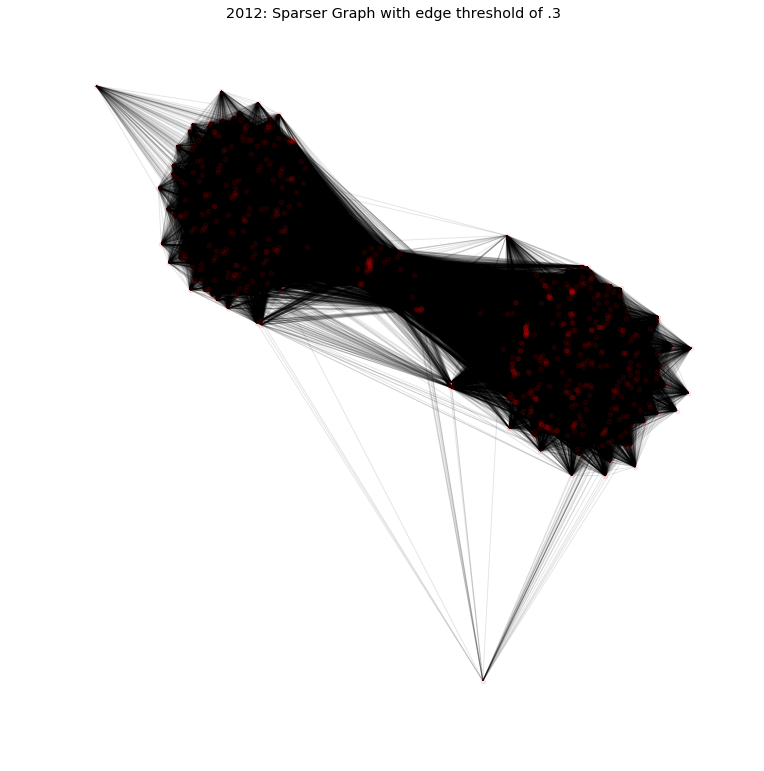

```python
plt.figure(figsize=(10, 10))
nx.draw_spring(ballot, node_size=100, node_shape = '.', linewidths=None,
                 alpha = 0.1, with_labels = False)
plt.title("2012: Sparser Graph with edge threshold of .3")
print('Density: {}, Diameter: {}'.format(nx.density(ballot), nx.diameter(ballot)))
```

We can now clearly see two camps in the network of MPs — most probably corresponding to the two main political parties, and some "centrist" politicians inbetween. This is a good representation of the french political scene at the time.

The network's density has gone down to 58% and its diameter is now 3. This kind of network seems much more manageable in terms of analysis.

#### In the following subsection, I try to get a little bit more formal about this choice of threshold and the sparsification process.

# "Sparsity"/Normalization of the Networks.

As the above exploration made clear, imposing some degree of sparsity on our networks can go a long way in making our graphs more interpretable and useful.

Though I am focusing on making the networks sparse via setting edges under a specified threshold to 0, let us note that many other methods could be used to get to the same results — e.g. imposing a maximum degree for each node.

### First, let's explore how the value of our threshold affects the density of our network.

I start by making a little twist to the `yearly matrix` function defined above to allow it to set all edges under a given threshold to 0.

```python
def yearly_sparse_matrix(ballots, threshold):
    matrices = [np.array(i) for i in ballots]
    fulladj = sum(matrices)/len(ballots)
    fulladj[fulladj < threshold] = 0
    return fulladj
```

**We are now ready to explore how our choice of threshold affects our graph**. I am moslty interested in:

- the density of the graph. This is what I would like to reduce in order to make the analysis more manageable.
- the number of isolate nodes (not connected to any other node) that I will have to drop by setting too-high a threshold — thus loosing information.

Ideally, I would like to find the right tradeoff between the two.

```python
# Impact of thresholds

results = pd.DataFrame(np.arange(0, 1, .05), columns = ['threshold'])
k = 2012
for j in [ballots2012, ballots2013, ballots2014, ballots2015, ballots2016]:
    num_isolates = []
    density = []
    for i in np.arange(0, 1, .05):
        ballot = nx.from_numpy_matrix(yearly_sparse_matrix(j, threshold = i))
        num_isolates.append(len(nx.isolates(ballot)))
        density.append(nx.density(ballot))
    results['num_isolates_{}'.format(k)] = num_isolates
    results['density_{}'.format(k)] = density
    k += 1
```

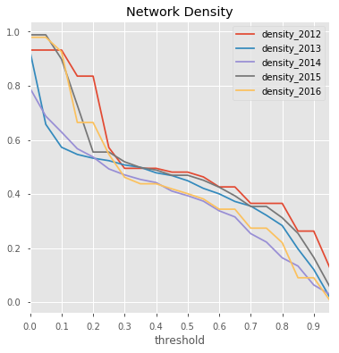

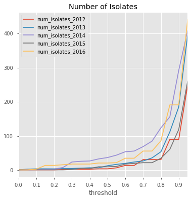

```python
results.plot(x="threshold", y = ["density_2012", "density_2013", "density_2014",
                                 "density_2015", "density_2016"], figsize = (6, 6),
             xticks=np.arange(0, 1, .1), title = "Network Density");
results.plot(x="threshold", y = ["num_isolates_2012", "num_isolates_2013", "num_isolates_2014",
                                 "num_isolates_2015", "num_isolates_2016"], figsize = (6, 6),
             xticks=np.arange(0, 1, .1), title = "Number of Isolates");
```

As the above simulation show, yearly networks are generally made much sparser when we drop edges of below .3. What this means is that a relatively high number of MPs agree less than 30% of the time. This seems to be a common feature across years: networks' densities all converge to about 50% when we only take into accounts links that represent an agreement more than 30% of the time.

Interestingly enough, the number of isolates (i.e. number of MPs who are not connected to any other MP) seems relatively robust to sparsification up to a threshold of about 50% (although this number is higher in 2014 and 2016). This suggests that most MPs are at least connected to the biggest portion of the network by one relatively strong link.

As we increase the threshold, we can subdivide the graph into smaller subgraphs: e.g. 2013, using a .5 threshold yields 2 subgraphs of length 246 and 324, respectively.

```python
ballot = nx.from_numpy_matrix(yearly_sparse_matrix(ballots2013, threshold = .5))
nx.isolates(ballot), nx.density(ballot)
ballot.remove_nodes_from(nx.isolates(ballot))
[len(i) for i in nx.connected_component_subgraphs(ballot)]
```

```
[246, 324]
```

Let's plot the number of different subgraphs created by each choice of threshold.

Our goal will be to make sure that our choice of network will not create too many of them, so that the resulting networks will still be interpretable.

```python
subg = pd.DataFrame(np.arange(0, 1, .05), columns=["threshold"])
```

```python
k = 2012
for j in [ballots2012, ballots2013, ballots2014, ballots2015, ballots2016]:
    subgroups = []
    for i in np.arange(0, 1, .05):
        ballot = nx.from_numpy_matrix(yearly_sparse_matrix(j, threshold = i))
        ballot.remove_nodes_from(nx.isolates(ballot)) #drop isolates
        subgroups.append(len([len(i) for i in nx.connected_component_subgraphs(ballot)]))
    subg["sub_{}".format(k)] = subgroups
    k += 1
```

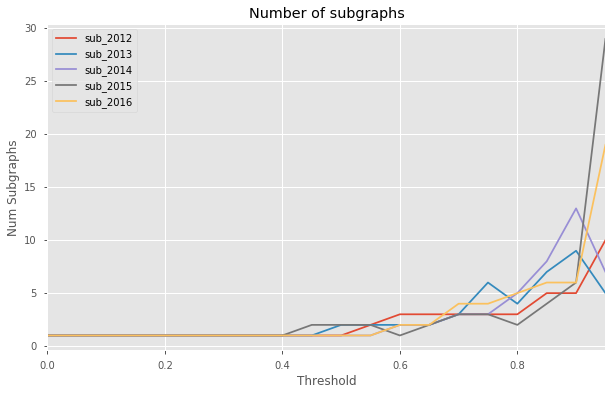

```python
subg.plot(x=0, figsize = (10, 6), title = 'Number of subgraphs');
plt.xlabel("Threshold");
plt.ylabel("Num Subgraphs");
```

As we can see, the network remains fully connected (i.e. at least 1 node is connected to both main of the network with $weight \geq threshold$) for threshold values up until 40% to 50% thresholds values.

# Yearly Analysis

For the following analysis, **I will use a threshold value of 50%** i.e. an edge between MP i and MP j exists only if MP i and MP j have voted similarily on at least 50% of a given year's ballots. As observed above, this should make visualization significantly easier while keeping most of the MPs in the networks once we drop isolates.

```python
yearly_graphs = [nx.from_numpy_matrix(yearly_sparse_matrix(i, threshold = .5)) for i in [ballots2012, ballots2013, ballots2014, ballots2015, ballots2016]]
```

```python
mapping = dict(zip(yearly_graphs[0].nodes(), ballots2012[0].index)) # create mapping node/MP
yearly_graphs[0] = nx.relabel_nodes(yearly_graphs[0], mapping, copy = False)

mapping = dict(zip(yearly_graphs[1].nodes(), ballots2013[0].index)) # create mapping node/MP
yearly_graphs[1] = nx.relabel_nodes(yearly_graphs[1], mapping, copy = False)

mapping = dict(zip(yearly_graphs[2].nodes(), ballots2014[0].index)) # create mapping node/MP
yearly_graphs[2] = nx.relabel_nodes(yearly_graphs[2], mapping, copy = False)

mapping = dict(zip(yearly_graphs[3].nodes(), ballots2015[0].index)) # create mapping node/MP
yearly_graphs[3] = nx.relabel_nodes(yearly_graphs[3], mapping, copy = False)

mapping = dict(zip(yearly_graphs[4].nodes(), ballots2016[0].index)) # create mapping node/MP
yearly_graphs[4] = nx.relabel_nodes(yearly_graphs[4], mapping, copy = False)
```

### Yearly summary statistics, threshold = 50%

```python
stats = pd.DataFrame(np.transpose([np.arange(2012, 2017),
              [len(nx.isolates(i)) for i in yearly_graphs],
              [nx.density(i) for i in yearly_graphs],
              [len([len(i) for i in nx.connected_component_subgraphs(j)]) for j in yearly_graphs]]),
             columns = ['Year', 'Number of Isolate MPs', 'Density', 'Num_Subgraphs'])

stats['Num_Subgraphs'] = stats['Num_Subgraphs'] - stats['Number of Isolate MPs']
stats
```

|  | Year | Number of Isolate MPs | Density | Num_Subgraphs |
| --- | --- | --- | --- | --- |
| 0 | 2012.0 | 4.0 | 0.480840 | 1.0 |
| 1 | 2013.0 | 13.0 | 0.449081 | 2.0 |
| 2 | 2014.0 | 37.0 | 0.393629 | 1.0 |
| 3 | 2015.0 | 10.0 | 0.469217 | 2.0 |
| 4 | 2016.0 | 21.0 | 0.401227 | 1.0 |

These results suggest that the years 2013 and 2015 were those where polarization was the strongest (the graphs are not fully-connected). There was more ballots in 2013 and it is rare that MPs attend all of them, so it is logically slightly harder for any given edge to rise above the 50% threshold.

Let's now draw the network for each year and try and see if we can see some MPs secceding from the majority group after 2014. Intuitively, we should observe more nodes in the middle of the graph as some MPs from the majority party started to vote *against* some of the government's proposals, just like the opposition!

```python
[i.remove_nodes_from(nx.isolates(i)) for i in yearly_graphs]; # drop isolates for plotting
```

[figure not shown]

```python
plt.figure(figsize = (20, 20))
k = 1
for i in yearly_graphs:
    plt.subplot(2, 3, k)
    plt.title('Year {}, Density = {}'.format(k + 2011, nx.density(i)))
    nx.draw_spring(i, node_size=100, node_shape = '.', linewidths=None,
                 alpha = 0.5, with_labels = False)
    k += 1
```

For 2015, one of the two subgraphs is only made of 2 MPs: **Jean-Paul Tuaiva** and **Maina Sage** (at the very top-right corner of the graph).

Interestingly enough, they are both reprensentatives from French Polynesian Islands. What this means is that they voted in the same way more than 50% of the time in 2015 but never more than 50% like *any* other MP.

This is quite remarkable, and it is a great example of what sort of information imposing a degree of sparsity to our networks can uncover!

```python
min(nx.connected_components(yearly_graphs[3]), key=len)
```

```
{'Jean-Paul Tuaiva', 'Maina Sage'}
```

I plot the above graphs once again, this time dropping 'Jean-Paul Tuaiva' and 'Maina Sage' (sorry).

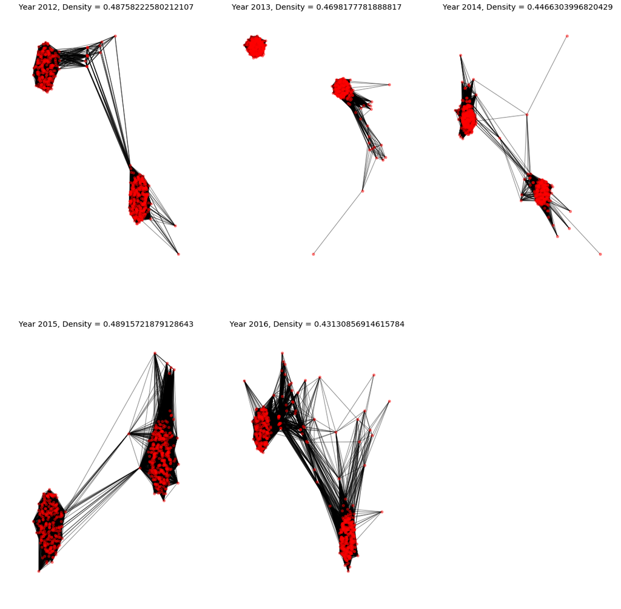

```python
yearly_graphs[3].remove_nodes_from({'Jean-Paul Tuaiva', 'Maina Sage'})

plt.figure(figsize = (20, 20))
k = 1
for i in yearly_graphs:
    plt.subplot(2, 3, k)
    plt.title('Year {}, Density = {}'.format(k + 2011, nx.density(i)))
    nx.draw_spring(i, node_size=100, node_shape = '.', linewidths=None,
                 alpha = 0.5, with_labels = False)
    k += 1
```

Looking at years 2014 - 2016 is particularly interesting!

2012 - 2014: roughly two well-defined camps, "as expected".

2015: each camp starts getting more spread out, indicating that MPs from each group are not as "tight" as before, this can be due to the fact that, as mentionned before, some MPs from the majority started to distance themselves from government's decisions.

2016: this process is accentuated and "lots" of MPs end up "inbetween" the two majority groups.

**It appears, therefore, that voting behavior can help us visualize political developments in the French National Assembly. Being able to color each node according to its party affiliation would be a great next step to this initial analysis.**

Finally, let's get each MP's number of connections (degree) for each year:

```python
# reload full data
yearly_graphs = [nx.from_numpy_matrix(yearly_sparse_matrix(i, threshold = .5)) for i in [ballots2012,
                                                                                         ballots2013,
                                                                                         ballots2014,
                                                                                         ballots2015,
                                                                                         ballots2016]]
for i in yearly_graphs:
    for ix,deg in i.degree().items():
        i.node[ix]['degree'] = deg
```

```python
pd.DataFrame(np.transpose([np.arange(2012, 2017), [np.mean(list(nx.degree(i).values())) for i in yearly_graphs],
    [np.median(list(nx.degree(i).values())) for i in yearly_graphs]]), columns = ['Year', 'Mean Degree', 'Median Degree'])
```

|  | Year | Mean Degree | Median Degree |
| --- | --- | --- | --- |
| 0 | 2012.0 | 276.963605 | 326.0 |
| 1 | 2013.0 | 261.365352 | 308.0 |
| 2 | 2014.0 | 237.752066 | 236.0 |
| 3 | 2015.0 | 273.084048 | 301.0 |
| 4 | 2016.0 | 237.125000 | 276.5 |

Generally speaking, tighter links between MPs in 2012 and 2015. 2014 and 2016 are the years with most polarization.

# A Simple — and context-relevant! — Measure of Centrality

It is fairly easy using the Networkx library to compute classic measures of centrality (Katz centrality, PageRank, eigenvalue centrality, etc...) for the National Assembly network.

However, I am here offering a simple model that is *context-relevant*. That is, it has a direct interpretation in the context of the National Assembly.

## The Lobbyist Model

### Setup

Let the (1 x N) vector $v_t$ represent the outcome of a vote at time t where $[v_{t}]_i = 1$ if MP i votes in favor of the law and 0 otherwise.

Imagine that at time t = 0, all MPs are against a given law, i.e. $v_0 = \overrightarrow{0}$

A lobbyist is only able to "convince" **a single MP** to become in favor of a law. This MP, however, will then be able to convince her fellow Members of Parliament to vote in favor of the law with probability $p_{ij}$:

$$p_{ij} = \frac{\text{Number of times when i and j voted the same way in the past}}{\text{Total Number of Votes}}$$

resulting in $v_1 = [0, 1, ... 1, ... 0]$ and $v_1 \cdot \iota_N = \text{number of MPs in favor of the law}$. ($\iota_N$ is a vector of ones).

### Given information on the historic voting behaviors of all MPs, the lobbyist's goal is therefore to choose this specific MP wisely so that the expected number of MPs who end up in favor of the law is maximized.

In other word, the lobbyist is **trying to select the most influential MP**, measured as the number and strength of links between her and other MPs.

### 1) Direct effect only (wave_1 influence)

Suppose we're only interested in the *direct* peer effect that "activating" (i.e. convincing) MP$_i$ will have on the outcome of the ballot. Deciding on who to focus is therefore fairly straigtforward: it is enough to sum the rows of the weighted adjacency matrix $P$ in order to obtain each MP's expected direct effect on its peers. We can compute the vector of expected direct effect as:

$$\mathbb{E}[\textit{wave_1_influence}] = P \cdot \iota_N$$

NB: this time, no sparsifying threshold is used.

```python
P = yearly_sparse_matrix(allballots, 0) # Full adj matrix, not sparse
ranking = pd.DataFrame(np.transpose([allballots[0].index, P.dot(np.ones(len(P)))]), # sum rows
                       columns= ["MP", "Expected_Direct_Influence"]) # store in df
ranking.sort_values("Expected_Direct_Influence", ascending = False).head() # sort
```

|  | MP | Expected_Direct_Influence |
| --- | --- | --- |
| 64 | Bruno Le Roux | 312.603 |
| 199 | Frédérique Massat | 312.603 |
| 113 | Corinne Erhel | 310.865 |
| 218 | Gisèle Biémouret | 310.849 |
| 575 | Sylviane Bulteau | 310.849 |

#### This simple approach already seems to do a great job at ranking MPs according to their influence!

According to our model, the lobbyist should convince **Bruno Le Roux** — who has led the Socialist Party (i.e. the majority party) in the National Assembly from 2012 until 2016! — in order to maximize the wave_1 number of MPs in favor of the law. This obviously makes a lot of sense: the head of the Majority group in the National Assembly typically gives "voting instructions" (*"consignes de votes"*) to the rest of the MPs from the majority.

**Frédérique Massat**, **Corinne Erhel**, **Gisèle Biémouret** and **Sylviane Bulteau** were also loyal members of the Socialist Party throughout the whole duration of the legislature (2012-2016).

```python
ranking.sort_values("Expected_Direct_Influence", ascending = True).head(6)
```

|  | MP | Expected_Direct_Influence |
| --- | --- | --- |
| 103 | Claude Bartolone | 0 |
| 242 | Henri Plagnol | 7.65873 |
| 138 | Dolores Roqué | 11.9206 |
| 207 | George Pau-Langevin | 15.6429 |
| 17 | Alain Vidalies | 19.0238 |
| 531 | Pierre Moscovici | 22.1429 |

At the bottom of the ranking are the **President of the National Assembly Claude Bartolone** (as mentionned before, he never votes, and this does not reflect his great political gravitas), **Henri Plagnol** who was only a MP for 3 month (his mandate was revoked because of electoral fraud allegations), and **Dolores Roqué** whose mandate also lasted 3 months. Similarily, **George Pau-Langevin** was a minister between 2012 and 2016 and only came back to the National Assembly for a few months after leaving the Government. **Alain Vidalies** and **Pierre Moscovici** were also Ministers.

All of those MPs would have been really bad choices for the lobbyist *in the setup of our model* (though not necessarily in real life, as "buying" yourself a minister in support of your law is probably a great way to get it passed...)

#### Here are some summary statistics for wave_1 influence in the network:

```python
ranking["Expected_Direct_Influence"] = ranking["Expected_Direct_Influence"].astype(np.float64) #convert
```

```
count    636.000000
mean     226.119672
std       68.922842
min        0.000000
0%         0.000000
5%        66.416667
10%      135.107143
15.0%    168.136905
20%      191.484127
25%      202.388889
30.0%    207.932540
35%      213.015873
40%      216.380952
45%      219.218254
50%      222.936508
55.0%    228.579365
60.0%    255.626984
65%      269.079365
70%      279.250000
75%      287.232143
80%      292.206349
85.0%    296.581349
90%      299.321429
95%      302.751984
100%     312.603175
max      312.603175
Name: Expected_Direct_Influence, dtype: float64
```

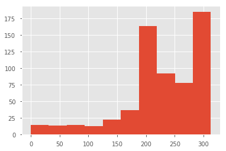

```python
print(ranking["Expected_Direct_Influence"].describe(percentiles = np.arange(0, 1.01, .05)))
plt.hist(ranking["Expected_Direct_Influence"].astype(np.float));
```